# Case Study 2: Bellabeat

Burçak Aydın

2023-02-06

Case Study: How Can a Wellness Technology Company Play It Smart?

# 1 Scenario

I am a junior data analyst working on the marketing analyst team at Bellabeat, a high-tech manufacturer of health-focused products for women. Bellabeat is a successful small company, but they have the potential to become a larger player in the global smart device market. Urška Sršen, cofounder and Chief Creative Officer of Bellabeat, believes that analyzing smart device fitness data could help unlock new growth opportunities for the company. I have been asked to focus on one of Bellabeat’s products and analyze smart device data to gain insight into how consumers are using their smart devices. I will guide marketing strategy for the company and present the analysis to the Bellabeat executive team along with your high-level recommendations for Bellabeat’s marketing strategy.

# 2 Business task

Based on trends in smart device usage, identify potential opportunities for growth and recommendations for the Bellabeat marketing strategy improvement.

## 2.1 Ask Question

1. What are some trends in smart device usage?
2. How could these trends apply to Bellabeat customers?
3. How could these trends help influence Bellabeat marketing strategy?

# 3 Preparation

## 3.1 Dataset Source

FitBit Fitness Tracker Data from “https://www.kaggle.com/arashnic/fitbit”(CC0: Public Domain, dataset made available through Mobius “https://www.kaggle.com/arashnic”): This Kaggle data set contains personal fitness tracker from thirty fitbit users. Thirty eligible Fitbit users consented to the submission of personal tracker data, including minute-level output for physical activity, heart rate, and sleep monitoring. It includes information about daily activity, steps, and heart rate that can be used to explore users’ habits.

## 3.2 Activating Libraries

```r
## Install Necessary Packages

library("tidyverse")
library("skimr")
library("janitor")
library("lubridate")
library("ggrepel")
library("readr")
library("data.table")
library("ggpubr")
library("here")
```

## 3.3 Importing and Merging Datasets

```r
daily_activity <- read_csv("dailyActivity_merged.csv")
daily_sleep <- read_csv("sleepDay_merged.csv")
hourly_steps <- read_csv("hourlySteps_merged.csv")
```

## 3.4 Getting Familiar with the Features of Dataset

```r
## Check the data
head(daily_activity,5)
```

```
## # A tibble: 5 × 15
##       Id Activ…¹ Total…² Total…³ Track…⁴ Logge…⁵ VeryA…⁶ Moder…⁷ Light…⁸ Seden…⁹
##    <dbl> <chr>     <dbl>   <dbl>   <dbl>   <dbl>   <dbl>   <dbl>   <dbl>   <dbl>
## 1 1.50e9 4/12/2…   13162    8.5     8.5        0    1.88   0.550    6.06       0
## 2 1.50e9 4/13/2…   10735    6.97    6.97       0    1.57   0.690    4.71       0
## 3 1.50e9 4/14/2…   10460    6.74    6.74       0    2.44   0.400    3.91       0
## 4 1.50e9 4/15/2…    9762    6.28    6.28       0    2.14   1.26     2.83       0
## 5 1.50e9 4/16/2…   12669    8.16    8.16       0    2.71   0.410    5.04       0
## # … with 5 more variables: VeryActiveMinutes <dbl>, FairlyActiveMinutes <dbl>,
## #   LightlyActiveMinutes <dbl>, SedentaryMinutes <dbl>, Calories <dbl>, and
## #   abbreviated variable names ¹ActivityDate, ²TotalSteps, ³TotalDistance,
## #   ⁴TrackerDistance, ⁵LoggedActivitiesDistance, ⁶VeryActiveDistance,
## #   ⁷ModeratelyActiveDistance, ⁸LightActiveDistance, ⁹SedentaryActiveDistance
```

```r
## Check the data
head(daily_sleep,5)
```

```
## # A tibble: 5 × 5
##           Id SleepDay              TotalSleepRecords TotalMinutesAsleep TotalT…¹
##        <dbl> <chr>                             <dbl>              <dbl>    <dbl>
## 1 1503960366 4/12/2016 12:00:00 AM                 1                327      346
## 2 1503960366 4/13/2016 12:00:00 AM                 2                384      407
## 3 1503960366 4/15/2016 12:00:00 AM                 1                412      442
## 4 1503960366 4/16/2016 12:00:00 AM                 2                340      367
## 5 1503960366 4/17/2016 12:00:00 AM                 1                700      712
## # … with abbreviated variable name ¹TotalTimeInBed
```

```r
## Check the data
head(hourly_steps,5)
```

```
## # A tibble: 5 × 3
##           Id ActivityHour          StepTotal
##        <dbl> <chr>                     <dbl>
## 1 1503960366 4/12/2016 12:00:00 AM       373
## 2 1503960366 4/12/2016 1:00:00 AM        160
## 3 1503960366 4/12/2016 2:00:00 AM        151
## 4 1503960366 4/12/2016 3:00:00 AM          0
## 5 1503960366 4/12/2016 4:00:00 AM          0
```

# 4 Process

## 4.1 Data Cleaning

```r
# Check NA
sum(duplicated(daily_activity))
```

```
## [1] 0
```

```r
sum(duplicated(daily_sleep))
```

```
## [1] 3
```

```r
sum(duplicated(hourly_steps))
```

```
## [1] 0
```

```r
## We drop all NA
daily_activity <- daily_activity %>%
  distinct() %>%
  drop_na()

daily_sleep <- daily_sleep %>%
  distinct() %>%
  drop_na()

hourly_steps <- hourly_steps %>%
  distinct() %>%
  drop_na()
```

## 4.2 Fixing Formatting

```r
##  Consistency for date and time columns in dataframes
daily_activity <- daily_activity %>%
  rename(date = ActivityDate) %>%
  mutate(date = as_date(date, format = "%m/%d/%Y"))

daily_sleep <- daily_sleep %>%
  rename(date = SleepDay) %>%
  mutate(date = as_date(date,format ="%m/%d/%Y %I:%M:%S %p" , tz=Sys.timezone()))
# Convert date string to date-time.
hourly_steps<- hourly_steps %>%
  rename(date_time = ActivityHour) %>%
  mutate(date_time = as.POSIXct(date_time,format ="%m/%d/%Y %I:%M:%S %p" , tz=Sys.timezone()))

head(hourly_steps)
```

```
## # A tibble: 6 × 3
##           Id date_time           StepTotal
##        <dbl> <dttm>                  <dbl>
## 1 1503960366 2016-04-12 00:00:00       373
## 2 1503960366 2016-04-12 01:00:00       160
## 3 1503960366 2016-04-12 02:00:00       151
## 4 1503960366 2016-04-12 03:00:00         0
## 5 1503960366 2016-04-12 04:00:00         0
## 6 1503960366 2016-04-12 05:00:00         0
```

```r
## Check data
head(daily_activity)
```

```
## # A tibble: 6 × 15
##           Id date       TotalS…¹ Total…² Track…³ Logge…⁴ VeryA…⁵ Moder…⁶ Light…⁷
##        <dbl> <date>        <dbl>   <dbl>   <dbl>   <dbl>   <dbl>   <dbl>   <dbl>
## 1 1503960366 2016-04-12    13162    8.5     8.5        0    1.88   0.550    6.06
## 2 1503960366 2016-04-13    10735    6.97    6.97       0    1.57   0.690    4.71
## 3 1503960366 2016-04-14    10460    6.74    6.74       0    2.44   0.400    3.91
## 4 1503960366 2016-04-15     9762    6.28    6.28       0    2.14   1.26     2.83
## 5 1503960366 2016-04-16    12669    8.16    8.16       0    2.71   0.410    5.04
## 6 1503960366 2016-04-17     9705    6.48    6.48       0    3.19   0.780    2.51
## # … with 6 more variables: SedentaryActiveDistance <dbl>,
## #   VeryActiveMinutes <dbl>, FairlyActiveMinutes <dbl>,
## #   LightlyActiveMinutes <dbl>, SedentaryMinutes <dbl>, Calories <dbl>, and
## #   abbreviated variable names ¹TotalSteps, ²TotalDistance, ³TrackerDistance,
## #   ⁴LoggedActivitiesDistance, ⁵VeryActiveDistance, ⁶ModeratelyActiveDistance,
## #   ⁷LightActiveDistance
```

```r
head(daily_sleep)
```

```
## # A tibble: 6 × 5
##           Id date       TotalSleepRecords TotalMinutesAsleep TotalTimeInBed
##        <dbl> <date>                 <dbl>              <dbl>          <dbl>
## 1 1503960366 2016-04-12                 1                327            346
## 2 1503960366 2016-04-13                 2                384            407
## 3 1503960366 2016-04-15                 1                412            442
## 4 1503960366 2016-04-16                 2                340            367
## 5 1503960366 2016-04-17                 1                700            712
## 6 1503960366 2016-04-19                 1                304            320
```

## 4.3 Merging Data

```r
# Merge daily_activity and daily_sleep to see any correlation between variables using primary keys as Id and date.

daily_activity_sleep <- merge(daily_activity, daily_sleep, by=c ("Id", "date"))
glimpse(daily_activity_sleep)
```

```
## Rows: 410
## Columns: 18
## $ Id                       <dbl> 1503960366, 1503960366, 1503960366, 150396036…
## $ date                     <date> 2016-04-12, 2016-04-13, 2016-04-15, 2016-04-…
## $ TotalSteps               <dbl> 13162, 10735, 9762, 12669, 9705, 15506, 10544…
## $ TotalDistance            <dbl> 8.50, 6.97, 6.28, 8.16, 6.48, 9.88, 6.68, 6.3…
## $ TrackerDistance          <dbl> 8.50, 6.97, 6.28, 8.16, 6.48, 9.88, 6.68, 6.3…
## $ LoggedActivitiesDistance <dbl> 0, 0, 0, 0, 0, 0, 0, 0, 0, 0, 0, 0, 0, 0, 0, …
## $ VeryActiveDistance       <dbl> 1.88, 1.57, 2.14, 2.71, 3.19, 3.53, 1.96, 1.3…
## $ ModeratelyActiveDistance <dbl> 0.55, 0.69, 1.26, 0.41, 0.78, 1.32, 0.48, 0.3…
## $ LightActiveDistance      <dbl> 6.06, 4.71, 2.83, 5.04, 2.51, 5.03, 4.24, 4.6…
## $ SedentaryActiveDistance  <dbl> 0, 0, 0, 0, 0, 0, 0, 0, 0, 0, 0, 0, 0, 0, 0, …
## $ VeryActiveMinutes        <dbl> 25, 21, 29, 36, 38, 50, 28, 19, 41, 39, 73, 3…
## $ FairlyActiveMinutes      <dbl> 13, 19, 34, 10, 20, 31, 12, 8, 21, 5, 14, 23,…
## $ LightlyActiveMinutes     <dbl> 328, 217, 209, 221, 164, 264, 205, 211, 262, …
## $ SedentaryMinutes         <dbl> 728, 776, 726, 773, 539, 775, 818, 838, 732, …
## $ Calories                 <dbl> 1985, 1797, 1745, 1863, 1728, 2035, 1786, 177…
## $ TotalSleepRecords        <dbl> 1, 2, 1, 2, 1, 1, 1, 1, 1, 1, 1, 1, 1, 1, 1, …
## $ TotalMinutesAsleep       <dbl> 327, 384, 412, 340, 700, 304, 360, 325, 361, …
## $ TotalTimeInBed           <dbl> 346, 407, 442, 367, 712, 320, 377, 364, 384, …
```

# 5 Analyze Data to Answer Questions

```r
## Calculate the daily steps average by user
daily_average <- daily_activity_sleep %>%
  group_by(Id) %>%
  summarise (mean_daily_steps = mean(TotalSteps), mean_daily_calories = mean(Calories), mean_daily_sleep = mean(TotalMinutesAsleep))

head(daily_average)
```

```
## # A tibble: 6 × 4
##           Id mean_daily_steps mean_daily_calories mean_daily_sleep
##        <dbl>            <dbl>               <dbl>            <dbl>
## 1 1503960366           12406.               1872.             360.
## 2 1644430081            7968.               2978.             294
## 3 1844505072            3477                1676.             652
## 4 1927972279            1490                2316.             417
## 5 2026352035            5619.               1541.             506.
## 6 2320127002            5079                1804               61
```

```r
# Classify users by the daily average steps.
user_type <- daily_average %>%
  mutate(user_type = case_when(
    mean_daily_steps < 5000 ~ "Sedentary",
    mean_daily_steps >= 5000 & mean_daily_steps < 7499 ~ "Lightly Active",
    mean_daily_steps >= 7500 & mean_daily_steps < 9999 ~ "Fairly Active",
    mean_daily_steps >= 10000 ~ "Very Active"
  ))

head(user_type)
```

```
## # A tibble: 6 × 5
##           Id mean_daily_steps mean_daily_calories mean_daily_sleep user_type
##        <dbl>            <dbl>               <dbl>            <dbl> <chr>
## 1 1503960366           12406.               1872.             360. Very Active
## 2 1644430081            7968.               2978.             294  Fairly Active
## 3 1844505072            3477                1676.             652  Sedentary
## 4 1927972279            1490                2316.             417  Sedentary
## 5 2026352035            5619.               1541.             506. Lightly Acti…
## 6 2320127002            5079                1804               61  Lightly Acti…
```

```r
## Calculate user type percentage
user_type_percent <- user_type %>%
  group_by(user_type) %>%
  summarise(total = n()) %>%
  mutate(totals = sum(total)) %>%
  group_by(user_type) %>%
  summarise(total_percent = total / totals) %>%
  mutate(labels = scales::percent(total_percent))

user_type_percent$user_type <- factor(user_type_percent$user_type , levels = c("Very Active", "Fairly Active", "Lightly Active", "Sedentary"))


head(user_type_percent)
```

```
## # A tibble: 4 × 3
##   user_type      total_percent labels
##   <fct>                  <dbl> <chr>
## 1 Fairly Active          0.375 38%
## 2 Lightly Active         0.208 21%
## 3 Sedentary              0.208 21%
## 4 Very Active            0.208 21%
```

# 6 Share Data Through Visuals

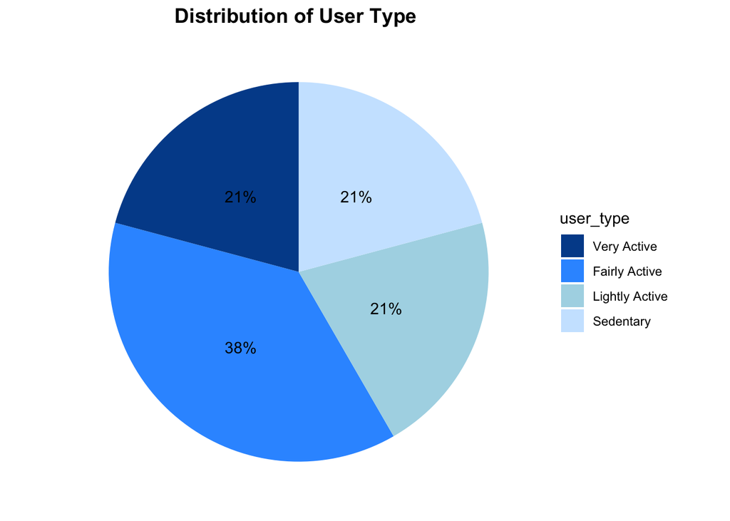

```r
## Ploting Distribution of User Type Graph
user_type_percent %>%
  ggplot(aes(x="",y=total_percent, fill=user_type)) +
  geom_bar(stat = "identity", width = 1)+
  coord_polar("y", start=0)+
  geom_text(aes(label = labels),
            position = position_stack(vjust = 0.5))+
  labs(title="Distribution of User Type ") +
  theme_minimal()+
  theme(axis.title.x= element_blank(),
        axis.title.y = element_blank(),
        panel.border = element_blank(),
        panel.grid = element_blank(),
        axis.ticks = element_blank(),
        axis.text.x = element_blank(),
        plot.title = element_text(hjust = 0.5, size=14, face = "bold")) +
  scale_fill_manual(values = c("#004d99", "#3399ff", "lightblue","#cce6ff"))
```

```r
# Calculating the average steps walked and minutes sleeped by weekday.

weekday_steps_sleep <- daily_activity_sleep %>%
  mutate(weekday = weekdays(date))

weekday_steps_sleep$weekday <-ordered(weekday_steps_sleep$weekday, levels=c("Monday", "Tuesday", "Wednesday", "Thursday",
"Friday", "Saturday", "Sunday"))

 weekday_steps_sleep <-weekday_steps_sleep%>%
  group_by(weekday) %>%
  summarize (daily_steps = mean(TotalSteps), daily_sleep = mean(TotalMinutesAsleep))

head(weekday_steps_sleep,7)
```

```
## # A tibble: 7 × 3
##   weekday   daily_steps daily_sleep
##   <ord>           <dbl>       <dbl>
## 1 Monday          9273.        420.
## 2 Tuesday         9183.        405.
## 3 Wednesday       8023.        435.
## 4 Thursday        8184.        401.
## 5 Friday          7901.        405.
## 6 Saturday        9871.        419.
## 7 Sunday          7298.        453.
```

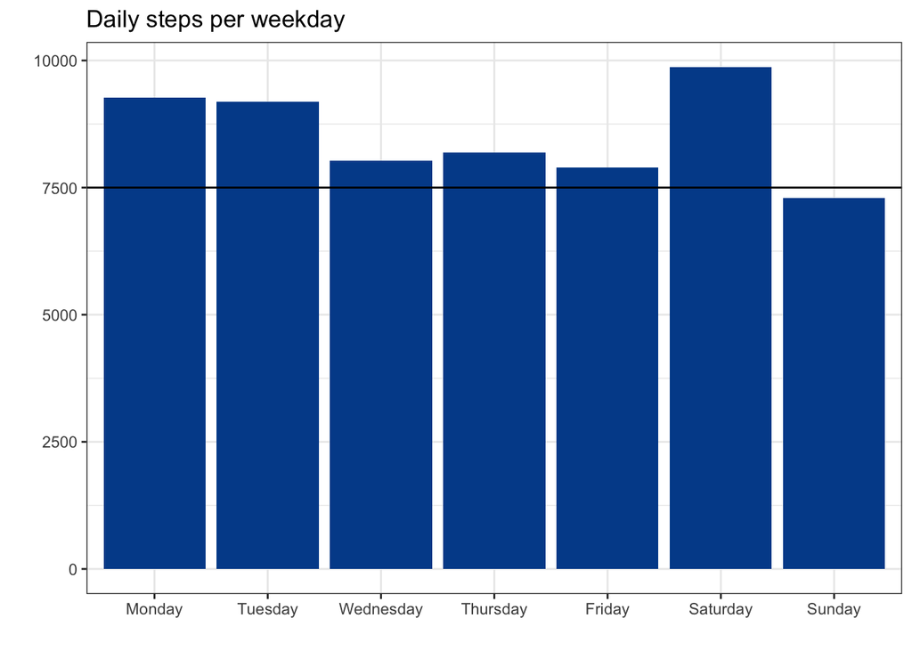

```r
## Ploting daily steps per weekday
ggplot(weekday_steps_sleep) +
      geom_col(aes(weekday, daily_steps), fill =  "#004d99") +
      geom_hline(yintercept = 7500) +
      labs(title = "Daily steps per weekday", x= "", y = "") +
      theme(axis.text.x = element_text(angle = 45,vjust = 0.5, hjust = 1))+
      theme_bw()
```

Saturday is most active day in steps

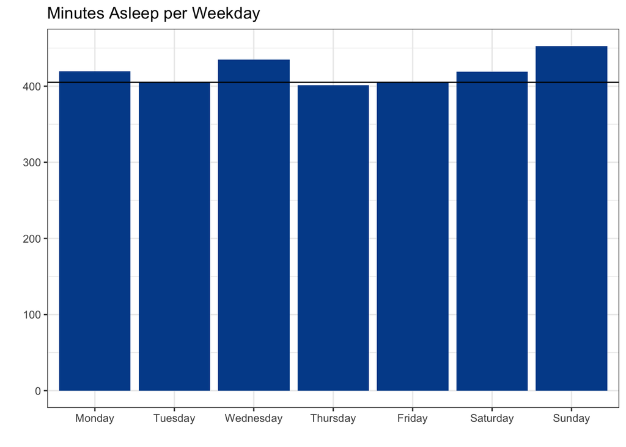

```r
# Plotting Minutes asleep per weekday

ggplot(weekday_steps_sleep, aes(weekday, daily_sleep)) +
  geom_col(fill = "#004d99") +
  geom_hline(yintercept = 405) +
  labs(title = "Minutes Asleep per Weekday", x= "", y = "") +
  theme(axis.text.x = element_text(angle = 45,vjust = 0.5, hjust = 1))+
  theme_bw()
```

```r
# Calculate hourly steps
hourly_steps <- hourly_steps %>%
  separate(date_time, into = c("date", "time"), sep= " ") %>%
  mutate(date = ymd(date))

head(hourly_steps)
```

```
## # A tibble: 6 × 4
##           Id date       time     StepTotal
##        <dbl> <date>     <chr>        <dbl>
## 1 1503960366 2016-04-12 00:00:00       373
## 2 1503960366 2016-04-12 01:00:00       160
## 3 1503960366 2016-04-12 02:00:00       151
## 4 1503960366 2016-04-12 03:00:00         0
## 5 1503960366 2016-04-12 04:00:00         0
## 6 1503960366 2016-04-12 05:00:00         0
```

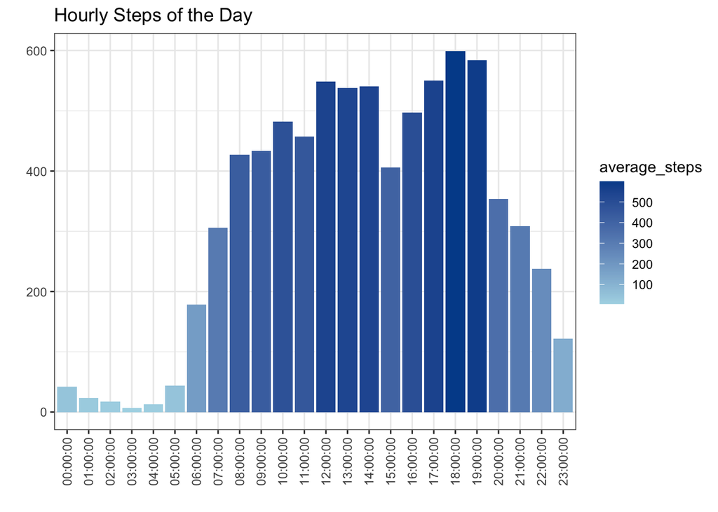

```r
# Plotting hourly steps of the day
hourly_steps %>%
  group_by(time) %>%
  summarize(average_steps = mean(StepTotal)) %>%
  ggplot() +
  theme_bw() +
  geom_col(mapping = aes(x=time, y = average_steps, fill = average_steps)) +
  labs(title = "Hourly Steps of the Day", x="", y="") +
  scale_fill_gradient(low = "lightblue", high = "#004d99")+
  theme(axis.text.x = element_text(angle = 90, vjust = 0.5, hjust=1))
```

Least steps time is between 00.00-05.00 which is home sleeping/resting time. Most active time is between 12.00-14.00 and 17.00-19.00

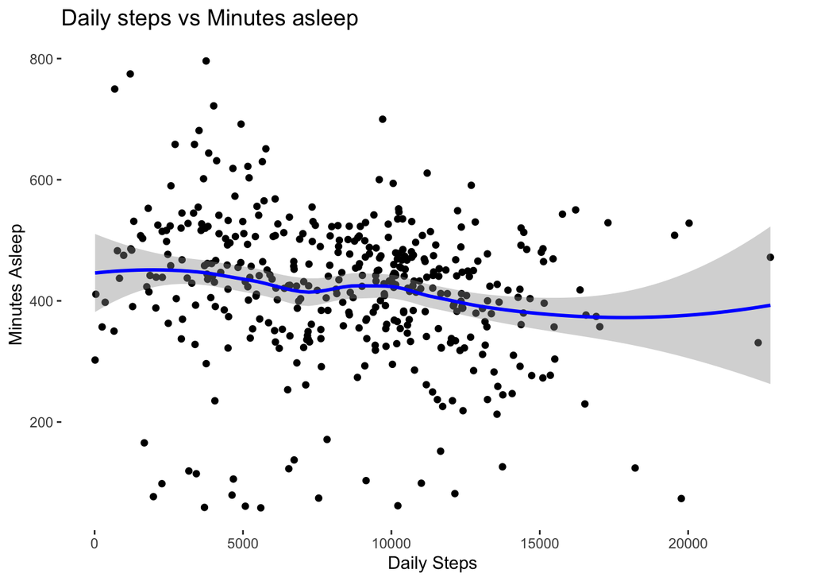

```r
# Correlation between variables

ggplot(daily_activity_sleep, aes(x=TotalSteps, y=TotalMinutesAsleep))+
  geom_jitter() +
  geom_smooth(color = "blue") +
  labs(title = "Daily steps vs Minutes asleep", x = "Daily Steps", y= "Minutes Asleep") +
   theme(panel.background = element_blank(),
        plot.title = element_text( size=14))
```

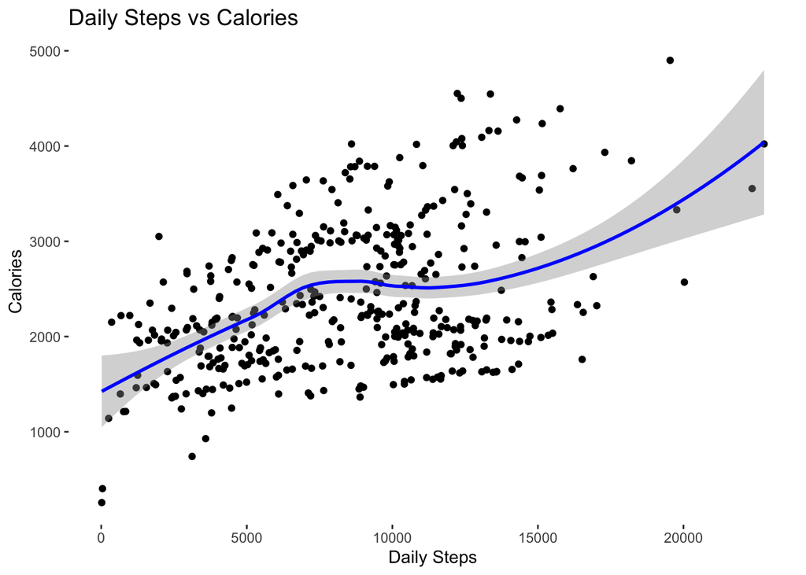

```r
# Correlation between variables
ggplot(daily_activity_sleep, aes(x=TotalSteps, y=Calories))+
        geom_jitter() +
        geom_smooth(color = "blue") +
        labs(title = "Daily Steps vs Calories", x = "Daily Steps", y= "Calories") +
         theme(panel.background = element_blank(),
              plot.title = element_text( size=14))
```

There is a positive correlation here between Total Steps and Calories which means that “the more active we are, the more calories we burn”.

```r
# Calculating number of daily use
daily_use <- daily_activity_sleep %>%
  group_by(Id) %>%
  summarize(days_used=sum(n())) %>%
  mutate(usage = case_when(
    days_used >= 1 & days_used <= 10 ~ "Low Use",
    days_used >= 11 & days_used <= 20 ~ "Moderate Use",
    days_used >= 21 & days_used <= 31 ~ "High Use",
  ))

head(daily_use,7)
```

```
## # A tibble: 7 × 3
##           Id days_used usage
##        <dbl>     <int> <chr>
## 1 1503960366        25 High Use
## 2 1644430081         4 Low Use
## 3 1844505072         3 Low Use
## 4 1927972279         5 Low Use
## 5 2026352035        28 High Use
## 6 2320127002         1 Low Use
## 7 2347167796        15 Moderate Use
```

```r
# # Calculating percentage of daily use
daily_use_percent <- daily_use %>%
  group_by(usage) %>%
  summarise(total = n()) %>%
  mutate(totals = sum(total)) %>%
  group_by(usage) %>%
  summarise(total_percent = total / totals) %>%
  mutate(labels = scales::percent(total_percent))

daily_use_percent$usage <- factor(daily_use_percent$usage, levels = c("High Use", "Moderate Use", "Low Use"))

head(daily_use_percent)
```

```
## # A tibble: 3 × 3
##   usage        total_percent labels
##   <fct>                <dbl> <chr>
## 1 High Use             0.5   50%
## 2 Low Use              0.375 38%
## 3 Moderate Use         0.125 12%
```

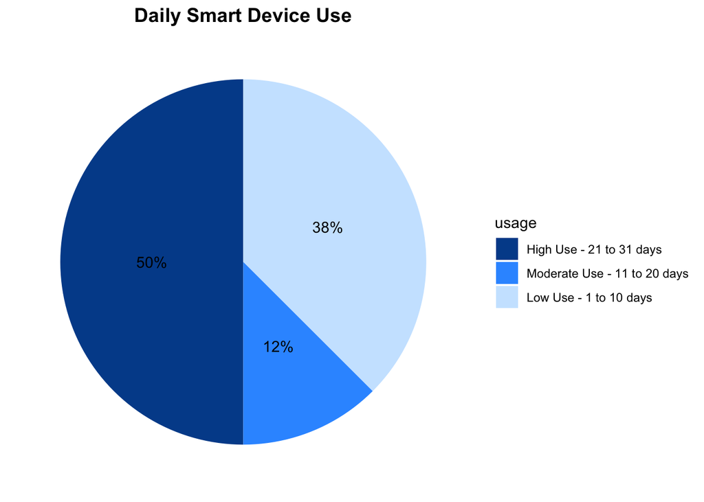

```r
# Plotting percentage of daily use
daily_use_percent %>%
  ggplot(aes(x="",y=total_percent, fill=usage)) +
  geom_bar(stat = "identity", width = 1)+
  coord_polar("y", start=0)+
  theme_minimal()+
  theme(axis.title.x= element_blank(),
        axis.title.y = element_blank(),
        panel.border = element_blank(),
        panel.grid = element_blank(),
        axis.ticks = element_blank(),
        axis.text.x = element_blank(),
        plot.title = element_text(hjust = 0.5, size=14, face = "bold")) +
  geom_text(aes(label = labels),
            position = position_stack(vjust = 0.5))+
  scale_fill_manual(values = c("#004d99", "#3399ff","#cce6ff"),
                    labels = c("High Use - 21 to 31 days",
                                 "Moderate Use - 11 to 20 days",
                                 "Low Use - 1 to 10 days"))+
  labs(title="Daily Smart Device Use")
```

```r
# Merge daily_activity and daily_use using key "Id"
daily_use_merged <- merge(daily_activity, daily_use, by=c ("Id"))
head(daily_use_merged)
```

```
##           Id       date TotalSteps TotalDistance TrackerDistance
## 1 1503960366 2016-05-07      11992          7.71            7.71
## 2 1503960366 2016-05-06      12159          8.03            8.03
## 3 1503960366 2016-05-01      10602          6.81            6.81
## 4 1503960366 2016-04-30      14673          9.25            9.25
## 5 1503960366 2016-04-12      13162          8.50            8.50
## 6 1503960366 2016-04-13      10735          6.97            6.97
##   LoggedActivitiesDistance VeryActiveDistance ModeratelyActiveDistance
## 1                        0               2.46                     2.12
## 2                        0               1.97                     0.25
## 3                        0               2.29                     1.60
## 4                        0               3.56                     1.42
## 5                        0               1.88                     0.55
## 6                        0               1.57                     0.69
##   LightActiveDistance SedentaryActiveDistance VeryActiveMinutes
```

[output cut: 20 more lines]

```r
# Calculating and grouping device usage in minutes
minutes_device_wearing <- daily_use_merged %>%
  mutate(total_minutes_wearing = VeryActiveMinutes+FairlyActiveMinutes+LightlyActiveMinutes+SedentaryMinutes)%>%
  mutate (percent_minutes_wearing = (total_minutes_wearing/1440)*100) %>%
  mutate (wearing = case_when(
    percent_minutes_wearing == 100 ~ "All day",
    percent_minutes_wearing < 100 & percent_minutes_wearing >= 50~ "More than half day",
    percent_minutes_wearing < 50 & percent_minutes_wearing > 0 ~ "Less than half day"
  ))

head(minutes_device_wearing)
```

```
##           Id       date TotalSteps TotalDistance TrackerDistance
## 1 1503960366 2016-05-07      11992          7.71            7.71
## 2 1503960366 2016-05-06      12159          8.03            8.03
## 3 1503960366 2016-05-01      10602          6.81            6.81
## 4 1503960366 2016-04-30      14673          9.25            9.25
## 5 1503960366 2016-04-12      13162          8.50            8.50
## 6 1503960366 2016-04-13      10735          6.97            6.97
##   LoggedActivitiesDistance VeryActiveDistance ModeratelyActiveDistance
## 1                        0               2.46                     2.12
## 2                        0               1.97                     0.25
## 3                        0               2.29                     1.60
## 4                        0               3.56                     1.42
## 5                        0               1.88                     0.55
## 6                        0               1.57                     0.69
##   LightActiveDistance SedentaryActiveDistance VeryActiveMinutes
```

[output cut: 20 more lines]

```r
# Calculating percentage device usage
minutes_wear_percent<- minutes_device_wearing%>%
  group_by(wearing) %>%
  summarise(total = n()) %>%
  mutate(totals = sum(total)) %>%
  group_by(wearing) %>%
  summarise(total_percent = total / totals) %>%
  mutate(labels = scales::percent(total_percent))
minutes_wear_percent
```

```
## # A tibble: 3 × 3
##   wearing            total_percent labels
##   <chr>                      <dbl> <chr>
## 1 All day                   0.365  36%
## 2 Less than half day        0.0351 4%
## 3 More than half day        0.600  60%
```

```r
# Calculating device usage by filtering "High Use"

minutes_wear_high_use <- minutes_device_wearing%>%
  filter (usage == "High Use")%>%
  group_by(wearing) %>%
  summarise(total = n()) %>%
  mutate(totals = sum(total)) %>%
  group_by(wearing) %>%
  summarise(total_percent = total / totals) %>%
  mutate(labels = scales::percent(total_percent))
minutes_wear_high_use
```

```
## # A tibble: 3 × 3
##   wearing            total_percent labels
##   <chr>                      <dbl> <chr>
## 1 All day                   0.0676 6.8%
## 2 Less than half day        0.0432 4.3%
## 3 More than half day        0.889  88.9%
```

```r
# Calculating device usage by filtering "Moderate Use"
minutes_wear_mod_use <-  minutes_device_wearing%>%
  filter(usage == "Moderate Use") %>%
  group_by(wearing) %>%
  summarise(total = n()) %>%
  mutate(totals = sum(total)) %>%
  group_by(wearing) %>%
  summarise(total_percent = total / totals) %>%
  mutate(labels = scales::percent(total_percent))
minutes_wear_mod_use
```

```
## # A tibble: 3 × 3
##   wearing            total_percent labels
##   <chr>                      <dbl> <chr>
## 1 All day                    0.267 27%
## 2 Less than half day         0.04  4%
## 3 More than half day         0.693 69%
```

```r
# Calculating device usage by filtering "Low Use"
minutes_wearing_low_use <- minutes_device_wearing%>%
  filter (usage == "Low Use") %>%
  group_by(wearing) %>%
  summarise(total = n()) %>%
  mutate(totals = sum(total)) %>%
  group_by(wearing) %>%
  summarise(total_percent = total / totals) %>%
  mutate(labels = scales::percent(total_percent))

 minutes_wearing_low_use
```

```
## # A tibble: 3 × 3
##   wearing            total_percent labels
##   <chr>                      <dbl> <chr>
## 1 All day                   0.802  80%
## 2 Less than half day        0.0224 2%
## 3 More than half day        0.175  18%
```

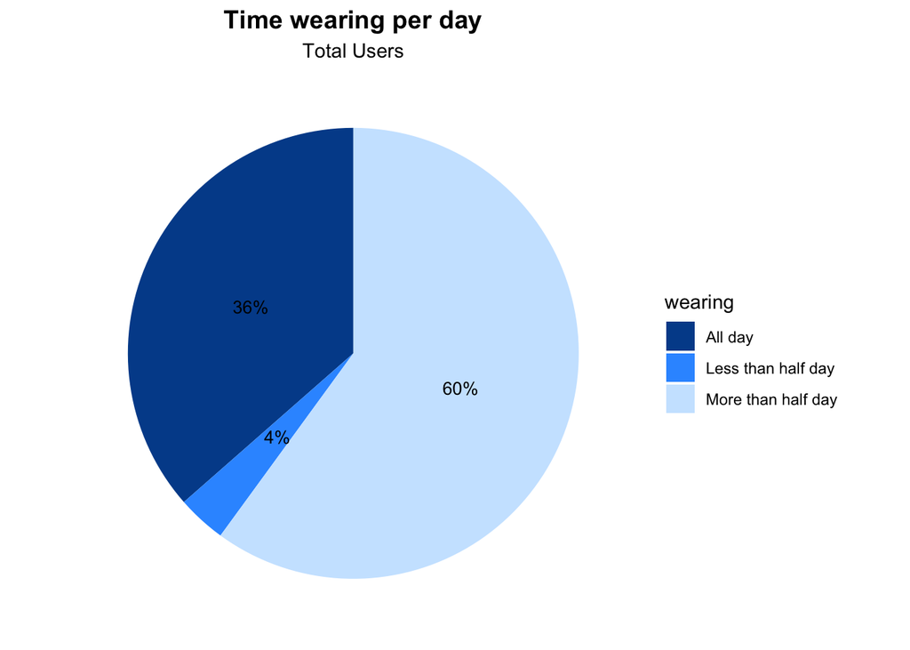

```r
# Plotting graph of time wearing per day
ggplot(minutes_wear_percent, aes(x="",y=total_percent, fill=wearing)) +
  geom_bar(stat = "identity", width = 1)+
  coord_polar("y", start=0)+
  theme_minimal()+
  theme(axis.title.x= element_blank(),
        axis.title.y = element_blank(),
        panel.border = element_blank(),
        panel.grid = element_blank(),
        axis.ticks = element_blank(),
        axis.text.x = element_blank(),
        plot.title = element_text(hjust = 0.5, size=14, face = "bold"),
        plot.subtitle = element_text(hjust = 0.5)) +
    scale_fill_manual(values = c("#004d99", "#3399ff", "#cce6ff"))+
  geom_text(aes(label = labels),
            position = position_stack(vjust = 0.5), size = 3.5)+
  labs(title="Time wearing per day", subtitle = "Total Users")
```

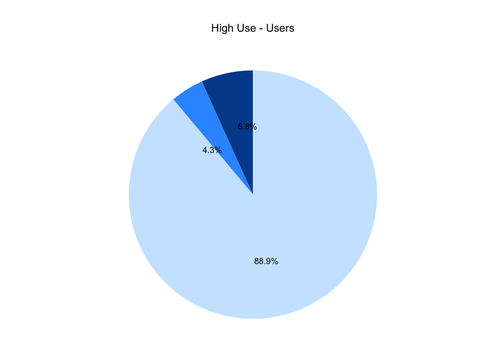

```r
# Plotting graph of time wearing per day with High Use - Users
ggplot(minutes_wear_high_use, aes(x="",y=total_percent, fill=wearing)) +
geom_bar(stat = "identity", width = 1)+
coord_polar("y", start=0)+
theme_minimal()+
theme(axis.title.x= element_blank(),
      axis.title.y = element_blank(),
      panel.border = element_blank(),
      panel.grid = element_blank(),
      axis.ticks = element_blank(),
      axis.text.x = element_blank(),
      plot.title = element_text(hjust = 0.5, size=14, face = "bold"),
      plot.subtitle = element_text(hjust = 0.5),
      legend.position = "none")+
  scale_fill_manual(values = c("#004d99", "#3399ff","#cce6ff"))+
geom_text_repel(aes(label = labels),
          position = position_stack(vjust = 0.5), size = 3)+
labs(title="", subtitle = "High Use - Users")
```

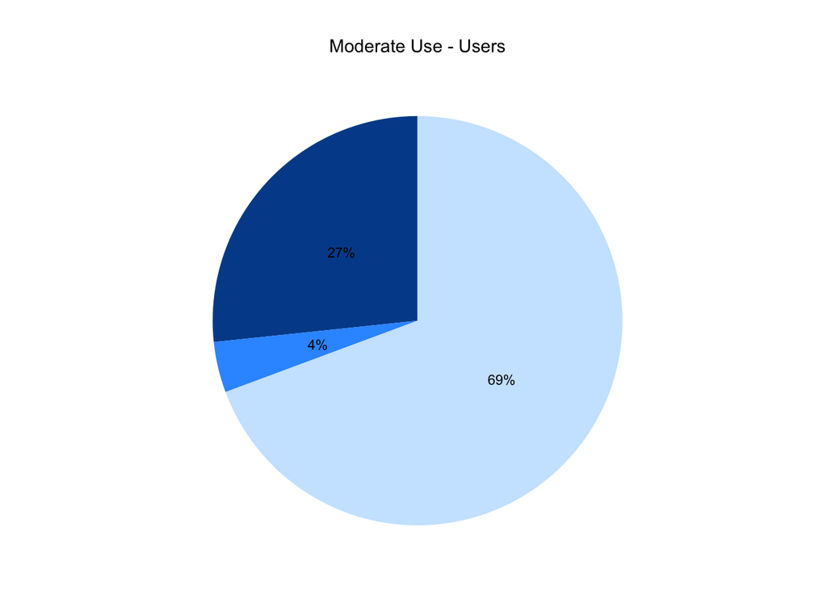

```r
# Plotting graph of time wearing per day with Moderate Use - Users
ggplot(minutes_wear_mod_use, aes(x="",y=total_percent, fill=wearing)) +
  geom_bar(stat = "identity", width = 1)+
  coord_polar("y", start=0)+
  theme_minimal()+
  theme(axis.title.x= element_blank(),
        axis.title.y = element_blank(),
        panel.border = element_blank(),
        panel.grid = element_blank(),
        axis.ticks = element_blank(),
        axis.text.x = element_blank(),
        plot.title = element_text(hjust = 0.5, size=14, face = "bold"),
        plot.subtitle = element_text(hjust = 0.5),
        legend.position = "none") +
    scale_fill_manual(values = c("#004d99", "#3399ff","#cce6ff"))+
  geom_text(aes(label = labels),
            position = position_stack(vjust = 0.5), size = 3)+
  labs(title="", subtitle = "Moderate Use - Users")
```

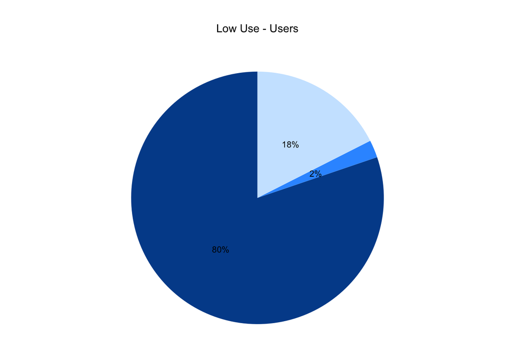

```r
# Plotting graph of time wearing per day with Low Use - Users
 ggplot(minutes_wearing_low_use, aes(x="",y=total_percent, fill=wearing)) +
  geom_bar(stat = "identity", width = 1)+
  coord_polar("y", start=0)+
  theme_minimal()+
  theme(axis.title.x= element_blank(),
        axis.title.y = element_blank(),
        panel.border = element_blank(),
        panel.grid = element_blank(),
        axis.ticks = element_blank(),
        axis.text.x = element_blank(),
        plot.title = element_text(hjust = 0.5, size=14, face = "bold"),
        plot.subtitle = element_text(hjust = 0.5),
        legend.position = "none") +
    scale_fill_manual(values = c("#004d99", "#3399ff", "#cce6ff"))+
  geom_text(aes(label = labels),
            position = position_stack(vjust = 0.5), size = 3)+
  labs(title="", subtitle = "Low Use - Users")
```

# 7 Conlusion

Remember the questions we asked in the beginning. 1. What are some trends in smart device usage? 2. How could these trends apply to Bellabeat customers? 3. How could these trends help influence Bellabeat marketing strategy?

The mission of Bellabeat is to empower women by providing them findings to discover themselves.

In order to respond the business task and help Bellabeat on their mission, I would recommend to use company’s own tracking data. Data sets used could be a big sample for further analysis. Demographic details of users such as age could be useful to see the trends of movement in different women group.